# Working with Different Object Types and Themes

Ronald G. Thomas

zztab2fig v0.2.0 introduced S3 method dispatch for `t2f()`, enabling direct conversion of statistical objects to publication-quality tables. This vignette demonstrates how different R object types are handled and how themes affect table appearance.

```r
library(zztab2fig)
```

# Object Types

## Data Frames

Data frames are the most common input type. The `t2f.data.frame()` method handles standard data frame objects with full formatting support.

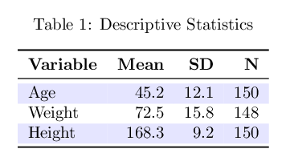

```r
df <- data.frame(
  Variable = c("Age", "Weight", "Height"),
  Mean = c(45.2, 72.5, 168.3),
  SD = c(12.1, 15.8, 9.2),
  N = c(150, 148, 150)
)

t2f(df, filename = "descriptive_stats", sub_dir = output_dir,
    caption = "Descriptive Statistics")
```

Data frames from dplyr pipelines work seamlessly:

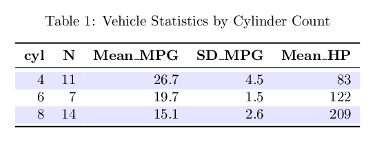

```r
library(dplyr)

summary_table <- mtcars |>
  group_by(cyl) |>
  summarise(
    N = n(),
    `Mean MPG` = round(mean(mpg), 1),
    `SD MPG` = round(sd(mpg), 1),
    `Mean HP` = round(mean(hp), 0),
    .groups = "drop"
  )

t2f(summary_table,
    filename = "cylinder_summary",
    caption = "Vehicle Statistics by Cylinder Count",
    sub_dir = output_dir)
```

## Matrices

Matrices are converted to data frames with optional row names as the first column via the `t2f.matrix()` method.

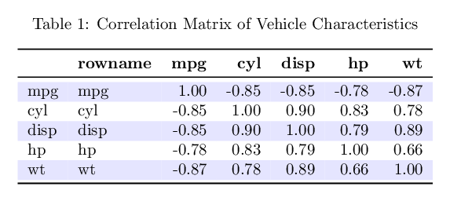

```r
cor_mat <- cor(mtcars[, c("mpg", "cyl", "disp", "hp", "wt")])
cor_mat <- round(cor_mat, 2)

t2f(cor_mat,
    filename = "correlation_matrix",
    caption = "Correlation Matrix of Vehicle Characteristics",
    rownames = TRUE,
    sub_dir = output_dir)
```

## Contingency Tables

Base R `table` objects are supported directly via the `t2f.table()` method.

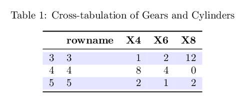

```r
gear_cyl_table <- table(mtcars$gear, mtcars$cyl)

t2f(gear_cyl_table,
    filename = "gear_cylinder_crosstab",
    caption = "Cross-tabulation of Gears and Cylinders",
    sub_dir = output_dir)
```

## Linear Models

The `t2f.lm()` method extracts coefficient tables from linear model objects. Control which statistics appear using the `include` parameter.

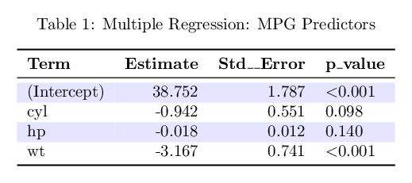

```r
model <- lm(mpg ~ cyl + hp + wt, data = mtcars)

t2f(model,
    filename = "regression_table",
    caption = "Multiple Regression: MPG Predictors",
    include = c("estimate", "std.error", "p.value"),
    digits = 3,
    sub_dir = output_dir)
```

Add confidence intervals (code only - full statistics):

```r
t2f(model,
    filename = "regression_with_ci",
    include = c("estimate", "std.error", "conf.int", "p.value"),
    conf.level = 0.95,
    sub_dir = output_dir)
```

## Generalized Linear Models

The `t2f.glm()` method supports logistic, Poisson, and other GLM families. Use `exponentiate = TRUE` to display odds ratios or rate ratios.

```r
logit_model <- glm(am ~ mpg + hp + wt,
                   data = mtcars,
                   family = binomial)

t2f(logit_model,
    filename = "logistic_odds_ratios",
    caption = "Logistic Regression: Odds Ratios",
    exponentiate = TRUE,
    include = c("estimate", "conf.int", "p.value"),
    sub_dir = output_dir)
```

[output not shown]

[figure not shown]

## ANOVA Tables

Both `aov` and `anova` objects are supported via `t2f.aov()` and `t2f.anova()`.

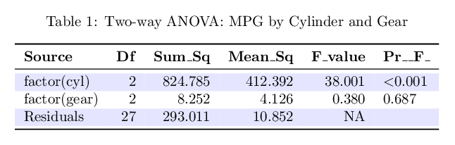

```r
aov_model <- aov(mpg ~ factor(cyl) + factor(gear), data = mtcars)

t2f(aov_model,
    filename = "anova_table",
    caption = "Two-way ANOVA: MPG by Cylinder and Gear",
    sub_dir = output_dir)
```

## Hypothesis Tests

The `t2f.htest()` method handles output from t-tests, chi-square tests, and other hypothesis testing functions.

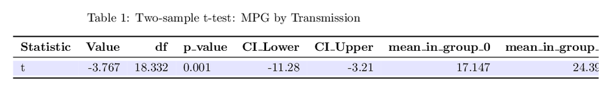

```r
ttest <- t.test(mpg ~ am, data = mtcars)

t2f(ttest,
    filename = "ttest_result",
    caption = "Two-sample t-test: MPG by Transmission",
    sub_dir = output_dir)
```

## Regression Model Comparisons

The `t2f_regression()` function creates side-by-side model comparison tables with significance stars.

```r
m1 <- lm(mpg ~ wt, data = mtcars)
m2 <- lm(mpg ~ wt + hp, data = mtcars)
m3 <- lm(mpg ~ wt + hp + cyl, data = mtcars)

t2f_regression(
  `(1)` = m1,
  `(2)` = m2,
  `(3)` = m3,
  stars = TRUE,
  digits = 3,
  filename = "model_progression",
  sub_dir = output_dir
)
```

[figure not shown]

## Additional Object Types via broom

zztab2fig v0.2.0 adds support for 13 additional statistical object types through broom integration. These methods use `broom::tidy()` to extract model information, then format the results.

### Survival Analysis (survival package)

```r
library(survival)

cox_model <- coxph(Surv(time, status) ~ age + sex, data = lung)
t2f(cox_model, exponentiate = TRUE, filename = "cox_hr")

survreg_model <- survreg(Surv(time, status) ~ age + sex, data = lung)
t2f(survreg_model, filename = "parametric_survival")

km_fit <- survfit(Surv(time, status) ~ sex, data = lung)
t2f(km_fit, filename = "kaplan_meier")
```

### Mixed Effects Models (lme4, nlme packages)

```r
library(lme4)

lmer_model <- lmer(mpg ~ cyl + (1 | gear), data = mtcars)
t2f(lmer_model, filename = "mixed_effects")

library(nlme)
lme_model <- lme(mpg ~ cyl, random = ~ 1 | gear, data = mtcars)
t2f(lme_model, filename = "nlme_model")
```

### Other Statistical Models

```r
nls_model <- nls(mpg ~ a * exp(b * wt), data = mtcars,
                 start = list(a = 40, b = -0.5))
t2f(nls_model, filename = "nonlinear")

library(MASS)
polr_model <- polr(factor(gear) ~ mpg + hp, data = mtcars)
t2f(polr_model, filename = "ordinal_logistic")
```

### Exploratory Analysis

```r
pca_result <- prcomp(mtcars[, 1:5], scale. = TRUE)
t2f(pca_result, matrix = "rotation", filename = "pca_loadings")
t2f(pca_result, matrix = "summary", filename = "pca_summary")

km_result <- kmeans(mtcars[, 1:5], centers = 3)
t2f(km_result, matrix = "centers", filename = "cluster_centers")
```

### Complete List of broom-Based Methods

| Object Class | Package | Method | Key Parameters |
| --- | --- | --- | --- |
| `coxph` | survival | `t2f.coxph()` | `exponentiate`, `conf.int` |
| `survreg` | survival | `t2f.survreg()` | `digits` |
| `survfit` | survival | `t2f.survfit()` | `times` |
| `survdiff` | survival | `t2f.survdiff()` | `digits` |
| `Arima` | stats | `t2f.Arima()` | `digits` |
| `nls` | stats | `t2f.nls()` | `conf.int` |
| `polr` | MASS | `t2f.polr()` | `exponentiate`, `conf.int` |
| `multinom` | nnet | `t2f.multinom()` | `exponentiate`, `conf.int` |
| `prcomp` | stats | `t2f.prcomp()` | `matrix` (rotation/summary) |
| `kmeans` | stats | `t2f.kmeans()` | `matrix` (centers/summary) |
| `lmerMod` | lme4 | `t2f.lmerMod()` | `effects`, `conf.int` |
| `glmerMod` | lme4 | `t2f.glmerMod()` | `effects`, `exponentiate` |
| `lme` | nlme | `t2f.lme()` | `effects` |

**Note**: These methods require the `broom` package (or `broom.mixed` for lme4/nlme models) and the respective model packages to be installed.

# Theme Demonstrations

Each built-in theme provides distinct styling appropriate for different publication contexts. Below are side-by-side comparisons using the same data.

```r
demo_data <- mtcars[1:6, c("mpg", "cyl", "hp", "wt")]
```

## Default Theme

The default styling uses blue row shading with booktabs rules.

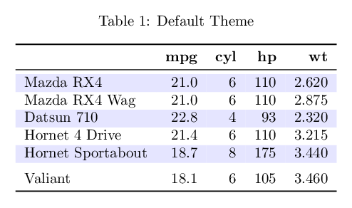

```r
t2f(demo_data,
    filename = "theme_default",
    caption = "Default Theme",
    sub_dir = output_dir)
```

## NEJM Theme

The New England Journal of Medicine theme provides clean, professional medical journal styling with light yellow shading and sans-serif fonts.

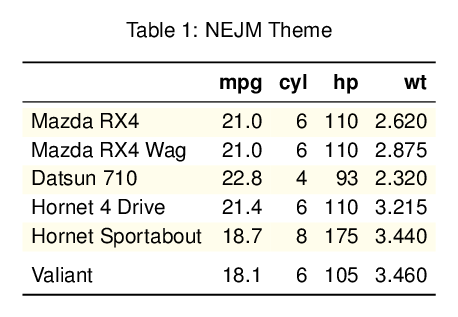

```r
t2f(demo_data,
    filename = "theme_nejm",
    caption = "NEJM Theme",
    theme = "nejm",
    sub_dir = output_dir)
```

NEJM theme characteristics:

- Light yellow alternating row colors
- Sans-serif font (Helvetica)
- Booktabs horizontal rules
- Compact column spacing (4pt)
- Footnotesize font

## APA Theme

The American Psychological Association theme follows APA 7th edition table guidelines.

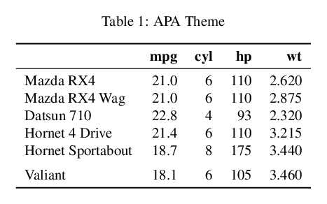

```r
t2f(demo_data,
    filename = "theme_apa",
    caption = "APA Theme",
    theme = "apa",
    sub_dir = output_dir)
```

APA theme characteristics:

- No row shading
- Times Roman font
- Letter paper with 1-inch margins
- Booktabs rules

## Nature Theme

The Nature journal theme uses Helvetica with subtle gray shading.

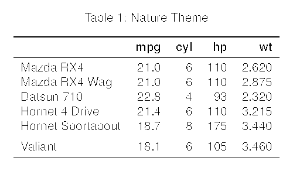

```r
t2f(demo_data,
    filename = "theme_nature",
    caption = "Nature Theme",
    theme = "nature",
    sub_dir = output_dir)
```

Nature theme characteristics:

- Light gray row shading (gray!8)
- Sans-serif font (Helvetica)
- Small font size
- 15mm margins

## Minimal Theme

The minimal theme provides clean, unobtrusive styling suitable for general use.

[figure not shown]

```r
t2f(demo_data,
    filename = "theme_minimal",
    caption = "Minimal Theme",
    theme = "minimal",
    sub_dir = output_dir)
```

# Custom Themes

Create custom themes for specific requirements using `t2f_theme()`.

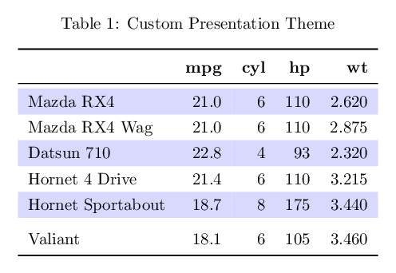

```r
presentation_theme <- t2f_theme(
  name = "presentation",
  scolor = "blue!15",
  header_bold = TRUE,
  font_size = "large",
  striped = TRUE,
  extra_packages = list(
    geometry(margin = "10mm"),
    "\\renewcommand{\\arraystretch}{1.3}"
  )
)

t2f(demo_data,
    filename = "theme_presentation",
    caption = "Custom Presentation Theme",
    theme = presentation_theme,
    sub_dir = output_dir)
```

# Global Theme Setting

Set a theme globally for consistent styling across multiple tables in an analysis.

```r
t2f_theme_set("nejm")

t2f(mtcars[1:5, 1:4], filename = "table1", sub_dir = "output")
t2f(iris[1:5, ], filename = "table2", sub_dir = "output")

model <- lm(mpg ~ wt + hp, data = mtcars)
t2f(model, filename = "table3", sub_dir = "output")

t2f(mtcars[1:5, 1:4],
    filename = "table4_apa",
    theme = "apa",
    sub_dir = "output")

t2f_theme_set(NULL)
```

# Summary

## Object Type Support (Base Methods)

| Object Class | Method | Key Parameters |
| --- | --- | --- |
| `data.frame` | `t2f.data.frame()` | Standard t2f parameters |
| `matrix` | `t2f.matrix()` | `rownames` |
| `table` | `t2f.table()` | Standard t2f parameters |
| `lm` | `t2f.lm()` | `digits`, `include`, `conf.level` |
| `glm` | `t2f.glm()` | `digits`, `include`, `exponentiate`, `conf.level` |
| `aov` | `t2f.aov()` | `digits` |
| `anova` | `t2f.anova()` | `digits` |
| `htest` | `t2f.htest()` | `digits` |

## Object Type Support (via broom)

| Object Class | Package | Key Parameters |
| --- | --- | --- |
| `coxph`, `survreg`, `survfit`, `survdiff` | survival | `exponentiate` |
| `nls` | stats | `conf.int` |
| `polr`, `multinom` | MASS, nnet | `exponentiate` |
| `prcomp`, `kmeans` | stats | `matrix` |
| `lmerMod`, `glmerMod` | lme4 | `effects` |
| `lme` | nlme | `effects` |
| `Arima` | stats | `digits` |

## Theme Comparison

| Theme | Row Shading | Font | Use Case |
| --- | --- | --- | --- |
| Default | blue!10 | Serif | General purpose |
| NEJM | yellow!8 | Helvetica | Medical journals |
| APA | None | Times | Psychology/social sciences |
| Nature | gray!8 | Helvetica | Scientific journals |
| Minimal | gray!5 | Serif | Clean, simple tables |

## Theme Functions

| Function | Purpose |
| --- | --- |
| `t2f_theme()` | Create custom theme |
| `t2f_theme_set()` | Set global theme |
| `t2f_theme_get()` | Get current global theme |
| `t2f_theme_nejm()` | NEJM preset |
| `t2f_theme_apa()` | APA preset |
| `t2f_theme_nature()` | Nature preset |
| `t2f_theme_minimal()` | Minimal preset |
| `t2f_list_themes()` | List available themes |